# Reproducible Results - Peer Assignment #1

AS

Sunday, September 14, 2014

```r
setwd("C:/Users/Dell/Desktop/Coursera")

              activity <- read.csv('activity.csv',
                    header=TRUE,   sep=",",
                    colClasses=c("numeric", "character", "numeric"))
        activity$interval <- factor(activity$interval)
        activity$date <- as.Date(activity$date, format="%Y-%m-%d")
```

## What is mean total number of steps taken per day?

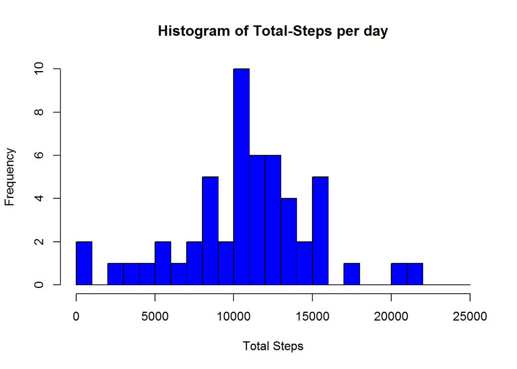

```r
stepsPerDay <- aggregate(steps ~ date, data=activity, FUN = sum)
hist(stepsPerDay$steps, col='blue',breaks=seq(0,25000,1000),
     main = "Histogram of Total-Steps per day", xlab="Total Steps")
```

```r
meanTotalSteps   <- mean(stepsPerDay$steps)
medianTotalSteps <- median(stepsPerDay$steps)
```

The value of Mean Total Steps is 1.0766 × 10<sup>4</sup> The value of Median Total Steps is 1.0765 × 10<sup>4</sup>

## What is the average daily activity pattern?

Time Series plot of the 5-minute Intervals and the avg. number of steps taken per day:

[figure not shown]

```r
intervals <- aggregate(steps ~ interval, data=activity, FUN = mean)
plot(intervals$interval, intervals$steps, type="l",
     ylab="Avg. Steps per Day", xlab="5min Interval",
     main="Avg. Daily Activity Pattern", col="yellow")
```

Time Interval with the maximum number of avg. steps per day:

```r
maxId <- which.max(intervals$steps)
intMax <- intervals$interval[maxId]
```

The Max ID is 104 The Interval of Maximum value is 835

## Imputing missing values.

```r
naId  <- which(is.na(activity$steps))
numNA <- length(naId)
```

The Number of missing values is 2304

Strategy and Code to impute missing values:use average value over all days of an interval.

```r
activityImputed <- activity
activityImputed$steps[naId] <- sapply(activityImputed[naId,"interval"],
                            function(a) {
                            id <- which(intervals[,"interval"]==a)
                            intervals[id,"steps"]
                            } )
```

Histogram of total number of steps per day after Imputing missing values:

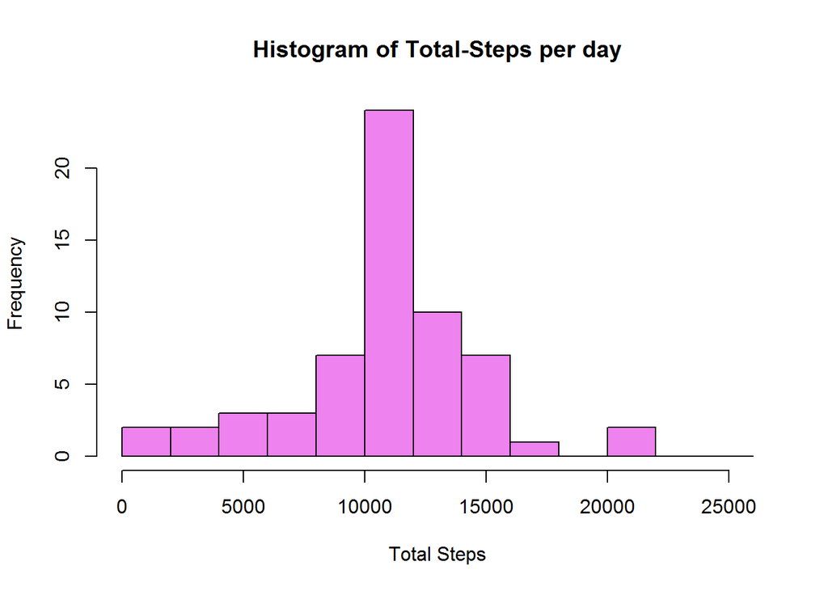

```r
stepsPerDayImputed <- aggregate(steps ~ date, data=activityImputed, FUN = sum)
hist(stepsPerDayImputed$steps, col='violet',breaks=seq(0,26000,2000),
     main = "Histogram of Total-Steps per day", xlab="Total Steps")
```

Imputed Mean and Median total number of steps per day.

```r
meanTotalStepsImputed   <- mean(stepsPerDayImputed$steps)
medianTotalStepsImputed <- median(stepsPerDayImputed$steps)
```

The Mean Total Steps after imputing is 1.0766 × 10<sup>4</sup> The Medial Total Steps after imputng is 1.0766 × 10<sup>4</sup> The results are more robust after using an average then if not used an average at all. Don’t know why average works well mathematically but intuitively it allows for use of a value in place of NA, i.e. lowering effects of NA, but not changing the overall values of the analysis.

Plotting Time intervals split on new ‘isweekday’ feature

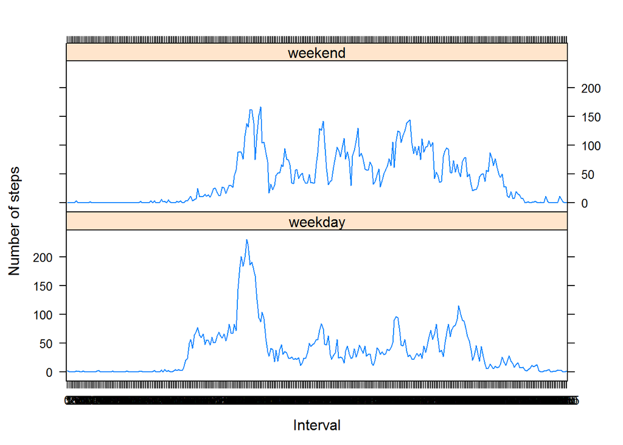

```r
library(lattice)
intervalsWeek <- aggregate(steps ~ interval + isweekday, data=activityWeek, FUN = mean)
xyplot(steps ~ interval | isweekday, data = intervalsWeek,
       layout = c(1, 2), type = "l",
       xlab = "Interval", ylab = "Number of steps")
```

The weekends activities are less variable than weekdays, and weekdays peak at ~835.